# Risk Management Project

## Data

https://www.kaggle.com/hadiyad/lendingclub-data-sets

LendingClub is a US peer-to-peer lending company, headquartered in San Francisco, California. It was the first peer-to-peer lender to register its offerings as securities with the Securities and Exchange Commission (SEC), and to offer loan trading on a secondary market. LendingClub is the world's largest peer-to-peer lending platform. Data preprocessed for demonstration purposes.

### Goal

Given historical data on loans given out with information on whether or not the borrower defaulted (charge-off), can we build a model thatcan predict wether or nor a borrower will pay back their loan? This way in the future when we get a new potential customer we can assess whether or not they are likely to pay back the loan.

|  | LoanStatNew | Description |
| --- | --- | --- |
| 0 | loan_amnt | The listed amount of the loan applied for by the borrower. If at some point in time, the credit department reduces the loan amount, then it will be reflected in this value. |
| 1 | term | The number of payments on the loan. Values are in months and can be either 36 or 60. |
| 2 | int_rate | Interest Rate on the loan |
| 3 | installment | The monthly payment owed by the borrower if the loan originates. |
| 4 | grade | LC assigned loan grade |
| 5 | sub_grade | LC assigned loan subgrade |
| 6 | emp_title | The job title supplied by the Borrower when applying for the loan.* |
| 7 | emp_length | Employment length in years. Possible values are between 0 and 10 where 0 means less than one year and 10 means ten or more years. |
| 8 | home_ownership | The home ownership status provided by the borrower during registration or obtained from the credit report. Our values are: RENT, OWN, MORTGAGE, OTHER |
| 9 | annual_inc | The self-reported annual income provided by the borrower during registration. |
| 10 | verification_status | Indicates if income was verified by LC, not verified, or if the income source was verified |
| 11 | issue_d | The month which the loan was funded |
| 12 | loan_status | Current status of the loan |
| 13 | purpose | A category provided by the borrower for the loan request. |
| 14 | title | The loan title provided by the borrower |
| 15 | zip_code | The first 3 numbers of the zip code provided by the borrower in the loan application. |
| 16 | addr_state | The state provided by the borrower in the loan application |
| 17 | dti | A ratio calculated using the borrower’s total monthly debt payments on the total debt obligations, excluding mortgage and the requested LC loan, divided by the borrower’s self-reported monthly income. |
| 18 | earliest_cr_line | The month the borrower's earliest reported credit line was opened |
| 19 | open_acc | The number of open credit lines in the borrower's credit file. |
| 20 | pub_rec | Number of derogatory public records |
| 21 | revol_bal | Total credit revolving balance |
| 22 | revol_util | Revolving line utilization rate, or the amount of credit the borrower is using relative to all available revolving credit. |
| 23 | total_acc | The total number of credit lines currently in the borrower's credit file |
| 24 | initial_list_status | The initial listing status of the loan. Possible values are – W, F |
| 25 | application_type | Indicates whether the loan is an individual application or a joint application with two co-borrowers |
| 26 | mort_acc | Number of mortgage accounts. |
| 27 | pub_rec_bankruptcies | Number of public record bankruptcies |

```python
%pip install numpy pandas matplotlib seaborn sklearn tensorflow
```

```python
import pandas as pd
```

```python
data_info = pd.read_csv('lending_club_info.csv',index_col='LoanStatNew')
```

```python
print(data_info.loc['revol_util']['Description'])
```

```
Revolving line utilization rate, or the amount of credit the borrower is using relative to all available revolving credit.
```

```python
def feat_info(col_name):
    print(data_info.loc[col_name]['Description'])
```

```python
feat_info('mort_acc')
```

```
Number of mortgage accounts.
```

## Loading the data and other imports

```python
import pandas as pd
import numpy as np
import matplotlib.pyplot as plt
import seaborn as sns

# to show graphs directly in Jupyter Notebook
%matplotlib inline
```

```python
df = pd.read_csv('lending_club_loan_two.csv')
```

```python
df.info()
```

```
<class 'pandas.core.frame.DataFrame'>
RangeIndex: 396030 entries, 0 to 396029
Data columns (total 27 columns):
 #   Column                Non-Null Count   Dtype
---  ------                --------------   -----
 0   loan_amnt             396030 non-null  float64
 1   term                  396030 non-null  object
 2   int_rate              396030 non-null  float64
 3   installment           396030 non-null  float64
 4   grade                 396030 non-null  object
 5   sub_grade             396030 non-null  object
 6   emp_title             373103 non-null  object
 7   emp_length            377729 non-null  object
 8   home_ownership        396030 non-null  object
 9   annual_inc            396030 non-null  float64
```

[output cut: 19 more lines]

# Section 1: Exploratory Data Analysis

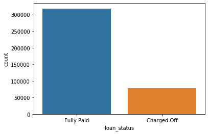

```python
sns.countplot(x="loan_status", data=df)
```

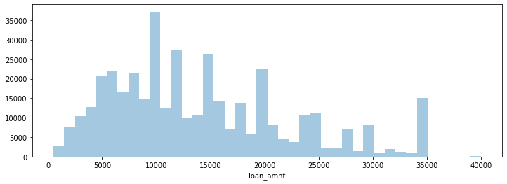

```python
plt.figure(figsize=(12,4))
sns.distplot(df["loan_amnt"], kde=False, bins=40)
```

```python
df.corr()
```

|  | loan_amnt | int_rate | installment | annual_inc | dti | open_acc | pub_rec | revol_bal | revol_util | total_acc | mort_acc | pub_rec_bankruptcies |
| --- | --- | --- | --- | --- | --- | --- | --- | --- | --- | --- | --- | --- |
| loan_amnt | 1.000000 | 0.168921 | 0.953929 | 0.336887 | 0.016636 | 0.198556 | -0.077779 | 0.328320 | 0.099911 | 0.223886 | 0.222315 | -0.106539 |
| int_rate | 0.168921 | 1.000000 | 0.162758 | -0.056771 | 0.079038 | 0.011649 | 0.060986 | -0.011280 | 0.293659 | -0.036404 | -0.082583 | 0.057450 |
| installment | 0.953929 | 0.162758 | 1.000000 | 0.330381 | 0.015786 | 0.188973 | -0.067892 | 0.316455 | 0.123915 | 0.202430 | 0.193694 | -0.098628 |
| annual_inc | 0.336887 | -0.056771 | 0.330381 | 1.000000 | -0.081685 | 0.136150 | -0.013720 | 0.299773 | 0.027871 | 0.193023 | 0.236320 | -0.050162 |
| dti | 0.016636 | 0.079038 | 0.015786 | -0.081685 | 1.000000 | 0.136181 | -0.017639 | 0.063571 | 0.088375 | 0.102128 | -0.025439 | -0.014558 |
| open_acc | 0.198556 | 0.011649 | 0.188973 | 0.136150 | 0.136181 | 1.000000 | -0.018392 | 0.221192 | -0.131420 | 0.680728 | 0.109205 | -0.027732 |
| pub_rec | -0.077779 | 0.060986 | -0.067892 | -0.013720 | -0.017639 | -0.018392 | 1.000000 | -0.101664 | -0.075910 | 0.019723 | 0.011552 | 0.699408 |
| revol_bal | 0.328320 | -0.011280 | 0.316455 | 0.299773 | 0.063571 | 0.221192 | -0.101664 | 1.000000 | 0.226346 | 0.191616 | 0.194925 | -0.124532 |
| revol_util | 0.099911 | 0.293659 | 0.123915 | 0.027871 | 0.088375 | -0.131420 | -0.075910 | 0.226346 | 1.000000 | -0.104273 | 0.007514 | -0.086751 |
| total_acc | 0.223886 | -0.036404 | 0.202430 | 0.193023 | 0.102128 | 0.680728 | 0.019723 | 0.191616 | -0.104273 | 1.000000 | 0.381072 | 0.042035 |
| mort_acc | 0.222315 | -0.082583 | 0.193694 | 0.236320 | -0.025439 | 0.109205 | 0.011552 | 0.194925 | 0.007514 | 0.381072 | 1.000000 | 0.027239 |
| pub_rec_bankruptcies | -0.106539 | 0.057450 | -0.098628 | -0.050162 | -0.014558 | -0.027732 | 0.699408 | -0.124532 | -0.086751 | 0.042035 | 0.027239 | 1.000000 |

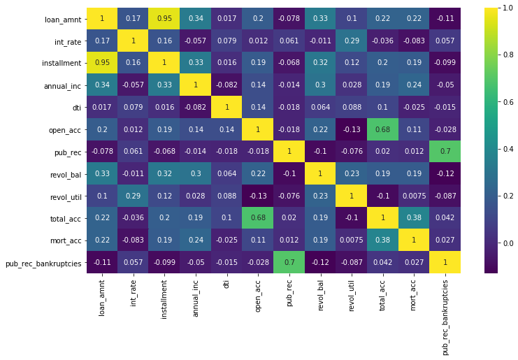

```python
plt.figure(figsize=(12,7))
sns.heatmap(df.corr(), annot=True, cmap="viridis")
```

```python
feat_info("installment")
```

```
The monthly payment owed by the borrower if the loan originates.
```

```python
feat_info("loan_amnt")
```

```
The listed amount of the loan applied for by the borrower. If at some point in time, the credit department reduces the loan amount, then it will be reflected in this value.
```

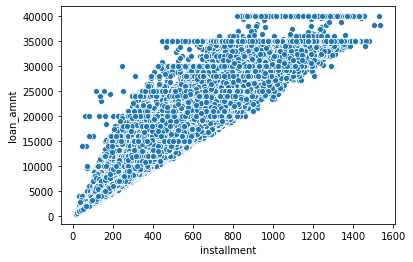

```python
sns.scatterplot(x="installment", y="loan_amnt", data=df)
```

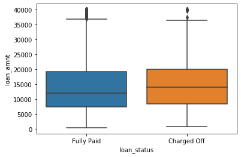

```python
sns.boxplot(x="loan_status", y="loan_amnt", data=df)
```

```python
df.groupby("loan_status")["loan_amnt"].describe()
```

| loan_status | count | mean | std | min | 25% | 50% | 75% | max |
| --- | --- | --- | --- | --- | --- | --- | --- | --- |
| Charged Off | 77673.0 | 15126.300967 | 8505.090557 | 1000.0 | 8525.0 | 14000.0 | 20000.0 | 40000.0 |
| Fully Paid | 318357.0 | 13866.878771 | 8302.319699 | 500.0 | 7500.0 | 12000.0 | 19225.0 | 40000.0 |

```python
df["grade"].unique()
```

```
array(['B', 'A', 'C', 'E', 'D', 'F', 'G'], dtype=object)
```

```python
df["sub_grade"].unique()
```

```
array(['B4', 'B5', 'B3', 'A2', 'C5', 'C3', 'A1', 'B2', 'C1', 'A5', 'E4',
       'A4', 'A3', 'D1', 'C2', 'B1', 'D3', 'D5', 'D2', 'E1', 'E2', 'E5',
       'F4', 'E3', 'D4', 'G1', 'F5', 'G2', 'C4', 'F1', 'F3', 'G5', 'G4',
       'F2', 'G3'], dtype=object)
```

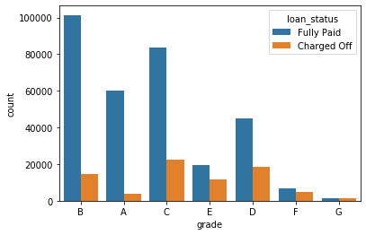

```python
sns.countplot(x="grade", data=df, hue="loan_status")
```

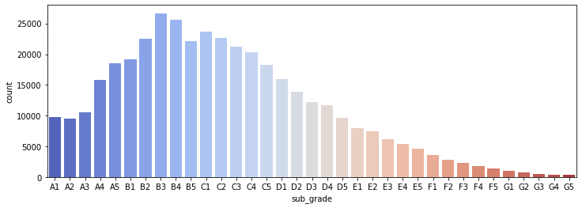

```python
plt.figure(figsize=(12,4))
subgrade_order = sorted(df["sub_grade"].unique())
sns.countplot(x="sub_grade", data=df, order=subgrade_order, palette="coolwarm")
```

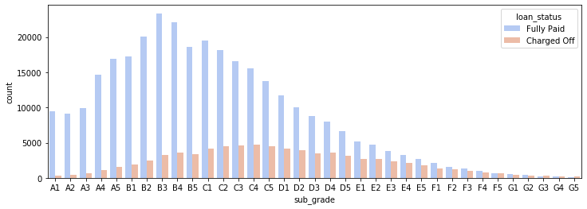

```python
plt.figure(figsize=(12,4))
subgrade_order = sorted(df["sub_grade"].unique())
sns.countplot(x="sub_grade", data=df, order=subgrade_order, palette="coolwarm", hue="loan_status")
```

**Isolate sub-grade F and G**

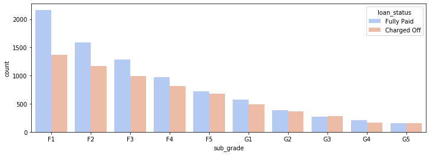

```python
f_and_g = df[(df["grade"]=="G") | (df["grade"]=="F")]
plt.figure(figsize=(12,4))
subgrade_order = sorted(f_and_g["sub_grade"].unique())
sns.countplot(x="sub_grade", data=f_and_g, order=subgrade_order, palette="coolwarm", hue="loan_status")
```

```python
df["loan_repaid"] = df["loan_status"].map({"Fully Paid":1, "Charged Off":0})
```

```python
df[["loan_repaid", "loan_status"]]
```

|  | loan_repaid | loan_status |
| --- | --- | --- |
| 0 | 1 | Fully Paid |
| 1 | 1 | Fully Paid |
| 2 | 1 | Fully Paid |
| 3 | 1 | Fully Paid |
| 4 | 0 | Charged Off |
| ... | ... | ... |
| 396025 | 1 | Fully Paid |
| 396026 | 1 | Fully Paid |
| 396027 | 1 | Fully Paid |
| 396028 | 1 | Fully Paid |
| 396029 | 1 | Fully Paid |

396030 rows × 2 columns

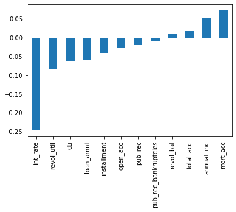

```python
df.corr()["loan_repaid"].sort_values().drop("loan_repaid").plot(kind="bar")
```

# Missing Data

```python
len(df)
```

```
396030
```

```python
df.isnull().sum()
```

```
loan_amnt                   0
term                        0
int_rate                    0
installment                 0
grade                       0
sub_grade                   0
emp_title               22927
emp_length              18301
home_ownership              0
annual_inc                  0
verification_status         0
issue_d                     0
loan_status                 0
purpose                     0
title                    1755
dti                         0
earliest_cr_line            0
open_acc                    0
pub_rec                     0
revol_bal                   0
revol_util                276
total_acc                   0
initial_list_status         0
application_type            0
mort_acc                37795
pub_rec_bankruptcies      535
address                     0
loan_repaid                 0
dtype: int64
```

```python
100 * df.isnull().sum()/len(df)
```

```
loan_amnt               0.000000
term                    0.000000
int_rate                0.000000
installment             0.000000
grade                   0.000000
sub_grade               0.000000
emp_title               5.789208
emp_length              4.621115
home_ownership          0.000000
annual_inc              0.000000
verification_status     0.000000
issue_d                 0.000000
loan_status             0.000000
purpose                 0.000000
title                   0.443148
dti                     0.000000
earliest_cr_line        0.000000
open_acc                0.000000
pub_rec                 0.000000
revol_bal               0.000000
revol_util              0.069692
total_acc               0.000000
initial_list_status     0.000000
application_type        0.000000
mort_acc                9.543469
pub_rec_bankruptcies    0.135091
address                 0.000000
loan_repaid             0.000000
dtype: float64
```

```python
feat_info("emp_title")
feat_info("emp_length")
```

```
The job title supplied by the Borrower when applying for the loan.*
Employment length in years. Possible values are between 0 and 10 where 0 means less than one year and 10 means ten or more years.
```

```python
df["emp_title"].nunique()
```

```
173105
```

```python
df["emp_title"].value_counts()
```

```
Teacher                              4389
Manager                              4250
Registered Nurse                     1856
RN                                   1846
Supervisor                           1830
                                     ...
City of Manchester NH                   1
Valet/Bell Serivce                      1
Adult Protective Community Worker       1
Mechanical Insulator / Lagger           1
Heartland Express of Iowa               1
Name: emp_title, Length: 173105, dtype: int64
```

```python
df = df.drop("emp_title", axis=1)
```

```python
sorted(df["emp_length"].dropna().unique())
```

```
['1 year',
 '10+ years',
 '2 years',
 '3 years',
 '4 years',
 '5 years',
 '6 years',
 '7 years',
 '8 years',
 '9 years',
 '< 1 year']
```

```python
emp_length_order = [ '< 1 year',
'1 year',
 '2 years',
 '3 years',
 '4 years',
 '5 years',
 '6 years',
 '7 years',
 '8 years',
 '9 years',
'10+ years'
]
```

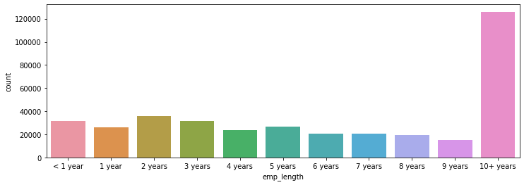

```python
plt.figure(figsize=(12,4))
sns.countplot(x="emp_length", data=df, order=emp_length_order)
```

**Seperated by Fully Paid vs Charged Off**

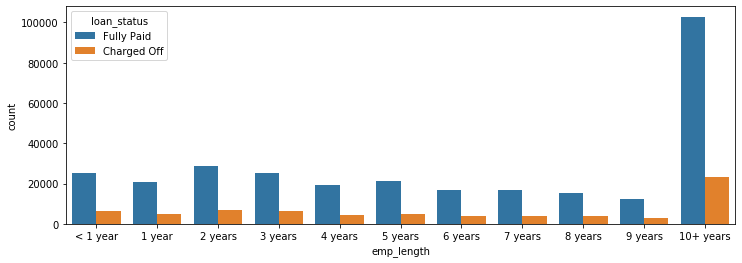

```python
plt.figure(figsize=(12,4))
sns.countplot(x="emp_length", data=df, order=emp_length_order, hue="loan_status")
```

```python
emp_co = df[df["loan_status"]=="Charged Off"].groupby("emp_length").count()["loan_status"]
```

```python
emp_fp = df[df["loan_status"]=="Fully Paid"].groupby("emp_length").count()["loan_status"]
```

```python
emp_co/emp_fp  # direct ratio
```

```
emp_length
1 year       0.248649
10+ years    0.225770
2 years      0.239560
3 years      0.242593
4 years      0.238213
5 years      0.237911
6 years      0.233341
7 years      0.241887
8 years      0.249625
9 years      0.250735
< 1 year     0.260830
Name: loan_status, dtype: float64
```

```python
emp_len = emp_co/(emp_co+emp_fp)  # percentage
```

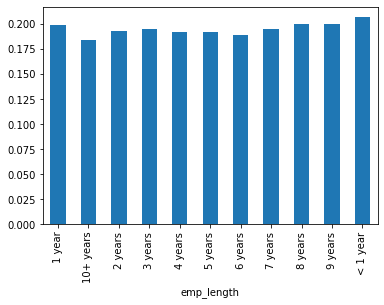

```python
emp_len.plot(kind="bar")
```

```python
df = df.drop("emp_length", axis=1)
```

```python
df.isnull().sum()
```

```
loan_amnt                   0
term                        0
int_rate                    0
installment                 0
grade                       0
sub_grade                   0
home_ownership              0
annual_inc                  0
verification_status         0
issue_d                     0
loan_status                 0
purpose                     0
title                    1755
dti                         0
earliest_cr_line            0
open_acc                    0
pub_rec                     0
revol_bal                   0
revol_util                276
total_acc                   0
initial_list_status         0
application_type            0
mort_acc                37795
pub_rec_bankruptcies      535
address                     0
loan_repaid                 0
dtype: int64
```

```python
feat_info("purpose")
```

```
A category provided by the borrower for the loan request.
```

```python
df['title'].head(10)
```

```
0                   Vacation
1         Debt consolidation
2    Credit card refinancing
3    Credit card refinancing
4      Credit Card Refinance
5         Debt consolidation
6           Home improvement
7       No More Credit Cards
8         Debt consolidation
9         Debt Consolidation
Name: title, dtype: object
```

```python
df = df.drop("title", axis=1)
```

```python
feat_info("mort_acc")
```

```
Number of mortgage accounts.
```

```python
df["mort_acc"].value_counts()
```

```
0.0     139777
1.0      60416
2.0      49948
3.0      38049
4.0      27887
5.0      18194
6.0      11069
7.0       6052
8.0       3121
9.0       1656
10.0       865
11.0       479
12.0       264
13.0       146
14.0       107
15.0        61
16.0        37
17.0        22
18.0        18
19.0        15
20.0        13
24.0        10
22.0         7
21.0         4
25.0         4
27.0         3
23.0         2
32.0         2
26.0         2
31.0         2
30.0         1
28.0         1
34.0         1
Name: mort_acc, dtype: int64
```

```python
df.corr()["mort_acc"].sort_values()
```

```
int_rate               -0.082583
dti                    -0.025439
revol_util              0.007514
pub_rec                 0.011552
pub_rec_bankruptcies    0.027239
loan_repaid             0.073111
open_acc                0.109205
installment             0.193694
revol_bal               0.194925
loan_amnt               0.222315
annual_inc              0.236320
total_acc               0.381072
mort_acc                1.000000
Name: mort_acc, dtype: float64
```

```python
df.groupby("total_acc").mean()["mort_acc"]
```

```
total_acc
2.0      0.000000
3.0      0.052023
4.0      0.066743
5.0      0.103289
6.0      0.151293
           ...
124.0    1.000000
129.0    1.000000
135.0    3.000000
150.0    2.000000
151.0    0.000000
Name: mort_acc, Length: 118, dtype: float64
```

```python
total_acc_avg = df.groupby("total_acc").mean()["mort_acc"]
```

**Fill missing with average value**

```python
def fill_mort_acc(total_acc, mort_acc):

    if np.isnan(mort_acc):
        return total_acc_avg[total_acc]
    else:
        return mort_acc
```

```python
df["mort_acc"] = df.apply(lambda x: fill_mort_acc(x["total_acc"], x["mort_acc"]), axis=1)
```

```python
df.isnull().sum()
```

```
loan_amnt                 0
term                      0
int_rate                  0
installment               0
grade                     0
sub_grade                 0
home_ownership            0
annual_inc                0
verification_status       0
issue_d                   0
loan_status               0
purpose                   0
dti                       0
earliest_cr_line          0
open_acc                  0
pub_rec                   0
revol_bal                 0
revol_util              276
total_acc                 0
initial_list_status       0
application_type          0
mort_acc                  0
pub_rec_bankruptcies    535
address                   0
loan_repaid               0
dtype: int64
```

```python
df = df.dropna()  # drop rows with missing values, here only missings left on revol_util and pub_rec_banktruptcies
```

```python
df.isnull().sum()
```

```
loan_amnt               0
term                    0
int_rate                0
installment             0
grade                   0
sub_grade               0
home_ownership          0
annual_inc              0
verification_status     0
issue_d                 0
loan_status             0
purpose                 0
dti                     0
earliest_cr_line        0
open_acc                0
pub_rec                 0
revol_bal               0
revol_util              0
total_acc               0
initial_list_status     0
application_type        0
mort_acc                0
pub_rec_bankruptcies    0
address                 0
loan_repaid             0
dtype: int64
```

## Deal with Categorical Variables and Dummy Variables

```python
df.select_dtypes(["object"]).columns
```

```
Index(['term', 'grade', 'sub_grade', 'home_ownership', 'verification_status',
       'issue_d', 'loan_status', 'purpose', 'earliest_cr_line',
       'initial_list_status', 'application_type', 'address'],
      dtype='object')
```

```python
feat_info("term")  # instruction function created here
```

```
The number of payments on the loan. Values are in months and can be either 36 or 60.
```

```python
df["term"].value_counts()
```

```
 36 months    301247
 60 months     93972
Name: term, dtype: int64
```

```python
df["term"] = df["term"].apply(lambda term: int(term[:3]))
```

```python
df["term"].value_counts()  # now it is a numeric column
```

```
36    301247
60     93972
Name: term, dtype: int64
```

**grade is part of sub_grade, so just drop the grade feature.**

```python
df = df.drop("grade", axis=1)
```

```python
dummies = pd.get_dummies(df["sub_grade"], drop_first=True)

df = pd.concat([df.drop("sub_grade", axis=1), dummies], axis=1)  # new df is old df minus sub_grade column concatenated with dummies
# do no forget the axis as we want to drop the column (axis=1) "sub_grade" and we want to concatenate the dummies as columns
```

```python
df.columns
```

```
Index(['loan_amnt', 'term', 'int_rate', 'installment', 'home_ownership',
       'annual_inc', 'verification_status', 'issue_d', 'loan_status',
       'purpose', 'dti', 'earliest_cr_line', 'open_acc', 'pub_rec',
       'revol_bal', 'revol_util', 'total_acc', 'initial_list_status',
       'application_type', 'mort_acc', 'pub_rec_bankruptcies', 'address',
       'loan_repaid', 'A2', 'A3', 'A4', 'A5', 'B1', 'B2', 'B3', 'B4', 'B5',
       'C1', 'C2', 'C3', 'C4', 'C5', 'D1', 'D2', 'D3', 'D4', 'D5', 'E1', 'E2',
       'E3', 'E4', 'E5', 'F1', 'F2', 'F3', 'F4', 'F5', 'G1', 'G2', 'G3', 'G4',
       'G5'],
      dtype='object')
```

```python
dummies = pd.get_dummies(df[['verification_status', 'application_type', 'initial_list_status', 'purpose']], drop_first=True)

df = pd.concat([df.drop(['verification_status', 'application_type','initial_list_status','purpose'], axis=1), dummies], axis=1)
# do the same for the list of features above
```

```python
df["home_ownership"].value_counts()
```

```
MORTGAGE    198022
RENT        159395
OWN          37660
OTHER          110
NONE            29
ANY              3
Name: home_ownership, dtype: int64
```

```python
df["home_ownership"] = df["home_ownership"].replace(["NONE", "ANY"], "OTHER")  # replace NONE, ANY to OTHER
```

```python
df["home_ownership"].value_counts()
```

```
MORTGAGE    198022
RENT        159395
OWN          37660
OTHER          142
Name: home_ownership, dtype: int64
```

```python
dummies = pd.get_dummies(df["home_ownership"], drop_first=True)  # Do the dummy dance again

df = pd.concat([df.drop("home_ownership", axis=1), dummies], axis=1)
```

### address, extract zip code

```python
df["zip_code"] = df["address"].apply(lambda address: address[-5:])  # grab zip code from address column
```

```python
df["zip_code"].value_counts()
```

```
70466    56880
22690    56413
30723    56402
48052    55811
00813    45725
29597    45393
05113    45300
11650    11210
93700    11126
86630    10959
Name: zip_code, dtype: int64
```

```python
dummies = pd.get_dummies(df["zip_code"], drop_first=True)  # Do the dummy dance again

df = pd.concat([df.drop("zip_code", axis=1), dummies], axis=1)
```

```python
df = df.drop("address", axis=1)  # drop original address column as we get the useful information from zip dummies
```

```python
feat_info("issue_d")  # In reality we would never have an issue_date, as our model should predict how likely it is
# that a person pays back their loan, so we apply it before we ever issue them a loan.
# Therefore this feature should not be used for a prediction model.
```

```
The month which the loan was funded
```

```python
df = df.drop("issue_d", axis=1)
```

### earliest_cr_line, extract year

```python
feat_info("earliest_cr_line")
```

```
The month the borrower's earliest reported credit line was opened
```

```python
df["earliest_cr_line"]
```

```
0         Jun-1990
1         Jul-2004
2         Aug-2007
3         Sep-2006
4         Mar-1999
            ...
396025    Nov-2004
396026    Feb-2006
396027    Mar-1997
396028    Nov-1990
396029    Sep-1998
Name: earliest_cr_line, Length: 395219, dtype: object
```

```python
df["earliest_cr_line"] = df["earliest_cr_line"].apply(lambda date: int(date[-4:]))  # grab last for characters of string to get year
```

```python
df["earliest_cr_line"]  # original column overwritten here
```

```
0         1990
1         2004
2         2007
3         2006
4         1999
          ...
396025    2004
396026    2006
396027    1997
396028    1990
396029    1998
Name: earliest_cr_line, Length: 395219, dtype: int64
```

## Train Test Split

```python
from sklearn.model_selection import train_test_split
```

```python
df = df.drop("loan_status", axis=1) # use loan_repaid now
```

**Set X and y variables to the .values of the features and label.**

```python
X = df.drop("loan_repaid", axis=1).values  # all columns except y-feature
```

```python
y = df["loan_repaid"].values  # only y-feature column
```

# OPTIONAL

## Grabbing a Sample for Training Time

```python
# df = df.sample(frac=0.1,random_state=101)
print(len(df))
```

```
395219
```

```python
X_train, X_test, y_train, y_test = train_test_split(X, y, test_size=0.2, random_state=101)
```

## Normalizing the Data

**Use a MinMaxScaler to normalize the feature data X_train and X_test.**

```python
from sklearn.preprocessing import MinMaxScaler
```

```python
scaler = MinMaxScaler()
```

```python
X_train = scaler.fit_transform(X_train)  # scale training data for model
```

```python
X_test = scaler.transform(X_test)  # scale training data already for later comparison
```

# Creating the Model

```python
import tensorflow as tf
from tensorflow.keras.models import Sequential
from tensorflow.keras.layers import Dense,Dropout
```

```python
X_train.shape
```

```
(316175, 78)
```

```python
model = Sequential()

model.add(Dense(78, activation="relu"))
model.add(Dropout(0.2))

model.add(Dense(39, activation="relu"))
model.add(Dropout(0.2))

model.add(Dense(19, activation="relu"))
model.add(Dropout(0.2))

model.add(Dense(units=1, activation="sigmoid"))  # sigmoid because we want a value between 0 and 1, aka default or repay

model.compile(loss="binary_crossentropy", optimizer="adam")
```

**Fit the model to the training data for 25 epochs. Also add in the validation data.**

```python
model.fit(x=X_train, y=y_train, epochs=25, batch_size=256, validation_data=(X_test, y_test))  # batch size important for larger data set
```

```
<tensorflow.python.keras.callbacks.History at 0x1681b9462c8>
```

**Save your model.**

```python
from tensorflow.keras.models import load_model
```

```python
model.save("modelLC.h5")  # save model at current state
```

# Evaluating Model Performance.

```python
losses = pd.DataFrame(model.history.history)
```

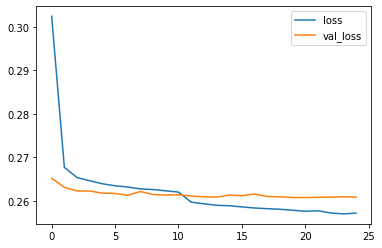

```python
losses.plot()
```

**Create predictions from the X_test set and display a classification report and confusion matrix for the X_test set.**

```python
from sklearn.metrics import classification_report, confusion_matrix
```

```python
predictions = model.predict_classes(X_test)
```

[output not shown]

```python
print(classification_report(y_test, predictions))
# true measure of success is f1-score of 0, aka harmonic mean of precision and recall for not repaid
```

```
              precision    recall  f1-score   support

           0       0.98      0.44      0.61     15658
           1       0.88      1.00      0.93     63386

    accuracy                           0.89     79044
   macro avg       0.93      0.72      0.77     79044
weighted avg       0.90      0.89      0.87     79044
```

```python
df["loan_repaid"].value_counts()
```

```
1    317696
0     77523
Name: loan_repaid, dtype: int64
```

```python
317696/len(df)  # 80% accuracy is the bottom, as just having a model that always predicts repaid would be 80% accurate
```

```
0.8038479931379817
```

```python
print(confusion_matrix(y_test, predictions))
```

```
[[ 6860  8798]
 [  106 63280]]
```

**Given the customer below, would you offer this person a loan?**

```python
import random
random.seed(101)
random_ind = random.randint(0,len(df))

new_customer = df.drop('loan_repaid',axis=1).iloc[random_ind]
new_customer
```

```
loan_amnt      25000.00
term              60.00
int_rate          18.24
installment      638.11
annual_inc     61665.00
                 ...
30723              1.00
48052              0.00
70466              0.00
86630              0.00
93700              0.00
Name: 305323, Length: 78, dtype: float64
```

```python
new_customer = scaler.transform(new_customer.values.reshape(1, 78))  # create numpy array from pandas seriens then scale
```

```python
model.predict_classes(new_customer)  # model predict this customer has repaid loan
```

```
array([[1]])
```

**Have they actually repaid their loan?**

```python
df.iloc[random_ind]["loan_repaid"]  # correct model guess in this instance
```

```
1.0
```